# Exercicio 8

> Dependencias

```r
library("quantmod")
library("xts")
library("moments")
library("dplyr")
```

## 8. Exercício Computacional - 8

Conceito explorado: Introdução à Análise de Séries Temporais Esse exercício tem o objetivo de explorar o assunto de séries temporais de forma introdutória. Para isso, existem alguns pacotes que podem nos auxiliar no objetivo desse exercício: capturar séries temporais do mercado financeiro e realizar sua visualização. Abaixo, estão listados três pacotes relacionados ao mercado financeiro que podem ser instalados e carregados na linguagem R. • install.packages(“quantmod”) • install.packages(“xts”) • install.packages(“moments”) Esses pacotes foram desenvolvidos exclusivamente para modelagem financeira quantitativa na linguagem R e permitem capturar séries temporais sobre as cotações de ações do mercado financeiro. Especificamente, estude e utilize a função getSymbols do pacote “quantmod” para obter séries temporais de diversas empresas presentes na bolsa de valores a partir de uma janela de tempo fornecida. Essa função consegue obter os dados diretamente das fontes “Yahoo Finance” (ainda ativo) e “Google Finance”, que disponibilizam os dados gratuitamente. Utilize o nome “yahoo” para designar a fonte de dados na função getSymbols. > 1) Use a função getSymbols do pacote quantmod para capturar as cotações de ações da empresa Petrobras de janeiro/2020 até os dias atuais.

```r
pricesPetro <- getSymbols("PETR4.SA",src="yahoo",  from=as.Date('2020-01-01'))
```

[output not shown]

> 2. Use a função candleChart do pacote quantmod para fazer a visualização da série temporal das cotações fechadas da Petrobras no período considerado. Pesquise e explore essa função; esse resultado é chamado de gráfico de velas (amplamente conhecido e usado em análises do mercado financeiro).

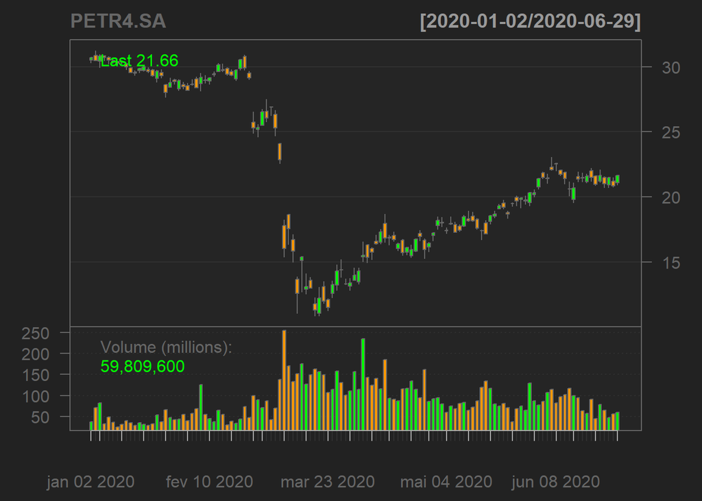

```r
candleChart(PETR4.SA)
```

> 3. Explore a série temporal obtida da empresa, teste outros períodos de tempo e identifique o significado dos campos trazidos da série.

```r
pricesPetro <- getSymbols("PETR4.SA",src="yahoo",  from=as.Date('2000-01-01'))
```

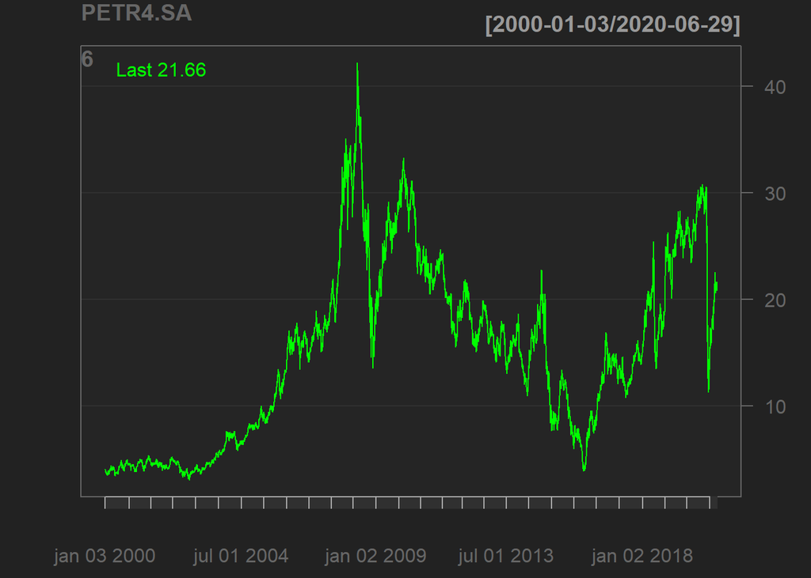

```r
from=as.Date('2000-06-01')

chartSeries(PETR4.SA[,6])
```

Testei com os dados apartir do ano 2000. da para verificar o impacto da crise de 2008, e a decida dos valores devido a crise de 2013~2016, a recuperação entre 2015 e 2019. e o impacto da covid nos preços da ação.

Os campos trazidos são: PETR4.SA.Open = valor na abertura de mercado. PETR4.SA.High = Valor mais alto durante o pregão. PETR4.SA.Low = Valor mais baixo dourante o pregão. PETR4.SA.Volume = Volume negociado. PETR4.SA.Adjusted = Preço da ação ajustado (ref: https://www.sunoresearch.com.br/artigos/preco-fechamento-ajustado/)

1). Podemos parametrizar a função fornecendo: i) o período da média móvel e ii) a quantidade de desvio padrão relacionados com os limites.

```r
pricesPetro <- getSymbols("PETR4.SA",src="yahoo",  from=as.Date('2019-01-01'))
```

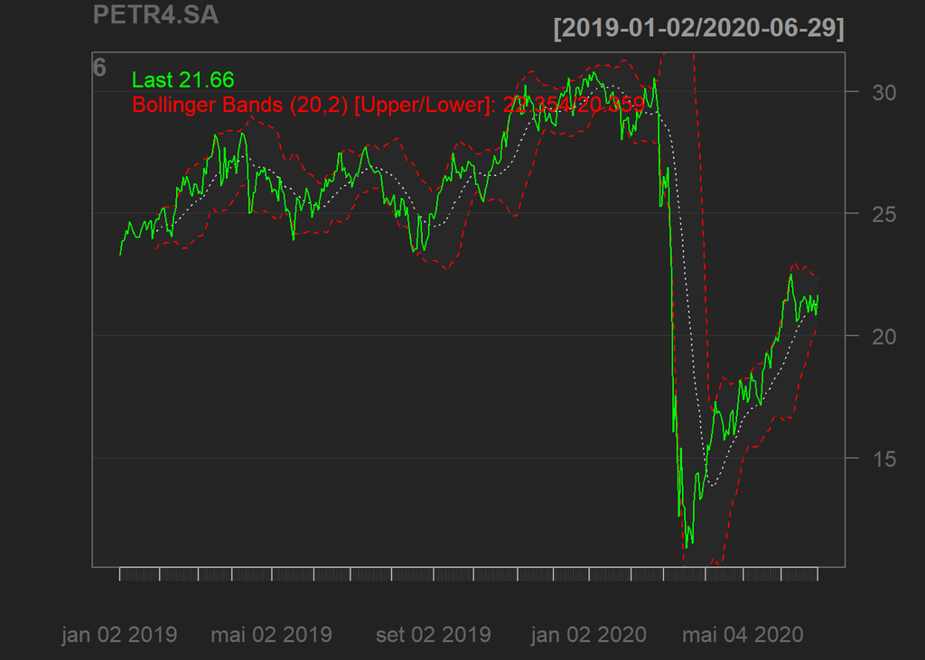

```r
from=as.Date('2000-06-01')

chartSeries(PETR4.SA[,6], TA="addBBands()")
```

> 5. A partir os itens anteriores, faça uma análise dos preços de cotações da Petrobras e verifique os reflexos do momento atual que estamos passando (março/abril/2020).

Da para verificar que a covid causou grande impacto nos preços da ação mas que o preço está se recuperando.